# Descriptive analysis of gut microbiota cohorts datasets

Author

Mariam Rahali Masbouri

Published

March 22, 2026

In this section, we will perform a descriptive analysis of the datasets used in this project.

## Importing the MAE object

```r
mae_file <-
  fs::dir_ls(str_c(data_dir(), "/02-processed-data"), regexp = "MAE_processed_.*\\.rds$") |>
  sort(decreasing = TRUE) |>
  magrittr::extract(1)


cat(str_c("Loading MultiAssayExperiment from: 00_data/", mae_file |> str_remove(data_dir()), "\n"))
```

```
Loading MultiAssayExperiment from: 00_data//02-processed-data/MAE_processed_20260321.rds
```

```r
mae <- readRDS(mae_file)

rm(mae_file)

mae
```

```
A MultiAssayExperiment object of 9 listed
 experiments with user-defined names and respective classes.
 Containing an ExperimentList class object of length 9:
 [1] IBD: SummarizedExperiment with 432 rows and 1630 columns
 [2] IBS: SummarizedExperiment with 598 rows and 62 columns
 [3] CDI: SummarizedExperiment with 868 rows and 366 columns
 [4] CRC: SummarizedExperiment with 837 rows and 575 columns
 [5] HMPV13: SummarizedExperiment with 660 rows and 171 columns
 [6] HMPV35: SummarizedExperiment with 1179 rows and 308 columns
 [7] NIBIOHN: SummarizedExperiment with 351 rows and 954 columns
 [8] MORINAGA: SummarizedExperiment with 281 rows and 642 columns
 [9] DIET: SummarizedExperiment with 193 rows and 114 columns
Functionality:
 experiments() - obtain the ExperimentList instance
 colData() - the primary/phenotype DataFrame
 sampleMap() - the sample coordination DataFrame
 `$`, `[`, `[[` - extract colData columns, subset, or experiment
 *Format() - convert into a long or wide DataFrame
 assays() - convert ExperimentList to a SimpleList of matrices
 exportClass() - save data to flat files
```

## IBD cohort (Franzosa et al., 2018)

We first import the IBD dataset from the MAE object in the chunk code below.

```r
tmp <-
  mae[["IBD"]] |>
  assay() |>
  t() |>
  as.data.frame() |>
  rownames_to_column("uid") |>
  pivot_longer(-uid, names_to = "taxon", values_to = "rel_ab") |>
  left_join(
    mae[["IBD"]] |> colData() |> as_tibble(rownames = "uid") |> select(uid, pid, visit_num, diagnosis),
    by = join_by(uid)
  )
```

We compute the number of taxa and samples in the dataset, to get an sense of the size of the dataset.

```r
n_taxa <- mae[["IBD"]] |> assay() |> nrow()
cat("Number of taxa:", n_taxa, "\n")
```

```
Number of taxa: 432
```

```r
n_samples <- mae[["IBD"]] |> assay() |> ncol()
cat("Number of samples:", n_samples, "\n")
```

```
Number of samples: 1630
```

```r
tmp |>
  group_by(pid, diagnosis) |>
  summarise(n_samples = n_distinct(uid), .groups = "drop") |>
  gt(caption = "Number of samples in the IBD dataset") |>
  tab_options(
    container.height = px(400)
  )
```

Number of samples in the IBD dataset

| pid | diagnosis | n_samples |
| --- | --- | --- |
| C3001 | CD | 16 |
| C3002 | CD | 15 |
| C3003 | UC | 10 |
| C3004 | UC | 24 |
| C3005 | UC | 12 |
| C3006 | UC | 11 |
| C3007 | CD | 3 |
| C3008 | CD | 13 |
| C3009 | CD | 12 |
| C3010 | CD | 14 |
| C3011 | UC | 22 |
| C3012 | CD | 14 |
| C3013 | UC | 22 |
| C3015 | UC | 23 |
| C3016 | CD | 20 |
| C3017 | CD | 23 |
| C3019 | CD | 1 |
| C3020 | CD | 1 |
| C3021 | CD | 9 |
| C3022 | nonIBD | 21 |
| C3023 | CD | 12 |
| C3024 | CD | 1 |
| C3027 | CD | 24 |
| C3028 | CD | 12 |
| C3029 | UC | 9 |
| C3030 | CD | 10 |
| C3031 | CD | 11 |
| C3032 | UC | 12 |
| C3033 | CD | 1 |
| C3034 | UC | 10 |

[output cut: 100 more lines]

```r
# separate healthy and IBD samples

mae[["IBD"]] |>
  colData() |>
  as.data.frame() |>
  as_tibble(rownames = "uid") |>
  mutate(
    status = case_when(
      diagnosis == "UC" ~ "Diseased",
      diagnosis == "CD" ~ "Diseased",
      TRUE ~ "Healthy"
    ),
    status = factor(status)
  ) |>
  dplyr::count(status) |>
  gt(caption = "Number of healthy and diseased samples in the IBS dataset")
```

| status | n |
| --- | --- |
| Diseased | 1202 |
| Healthy | 428 |

**Important**

Rarefaction cannot be applied to the IBD dataset, since counts are not available for this dataset, and only relative abundances are available.

- Richness = $\sum_{i=1}^{S} I(x_i > 0)$, where $S$ is the total number of taxa and $x_i$ is the abundance of taxon $i$ in the sample.
- Shannon = $-\sum_{i=1}^{S} p_i \log(p_i)$, where $p_i$ is the relative abundance of taxon $i$ in the sample.
- Pielou’s evenness = $\frac{-\sum_{i=1}^{S} p_i \log(p_i)}{\log(\sum_{i=1}^{S} I(x_i > 0))}$
- Sheldon evenness = $\frac{exp(-\sum_{i=1}^{S} p_i \log(p_i))}{\sum_{i=1}^{S} I(x_i > 0)}$
- Beta diversity will be computed using Bray-Curtis dissimilarity.

The difference between groups will be assessed using the Wilcoxon rank-sum test.

```r
bc_mat <- tmp |>
  select(uid, taxon, rel_ab) |>
  pivot_wider(names_from = taxon, values_from = rel_ab) |>
  column_to_rownames("uid") |>
  as.matrix()
```

```r
bc_per_sample <- vegan::vegdist(bc_mat, method = "bray") |>
  as.matrix() |>
  rowMeans() |>
  as_tibble(rownames = "uid") |>
  dplyr::rename(bc = value)
```

```r
bc_long <- vegan::vegdist(bc_mat, method = "bray") |>
  as.matrix() |>
  as_tibble(rownames = "sample1") |>
  pivot_longer(-sample1, names_to = "sample2", values_to = "bc") |>
  filter(sample1 < sample2)

sample_meta <- mae[["IBD"]] |>
  colData() |>
  as.data.frame() |>
  as_tibble(rownames = "uid") |>
  select(uid, pid, diagnosis)

bc_intra <- bc_long |>
  select(sample1, sample2, bc) |>
  left_join(sample_meta, by = c("sample1" = "uid")) |>
  select(sample1, sample2, bc, subject1 = pid, cohort1 = diagnosis) |>
  left_join(sample_meta, by = c("sample2" = "uid")) |>
  select(sample1, sample2, bc, subject1, cohort1, subject2 = pid, cohort2 = diagnosis) |>
  filter(subject1 == subject2) |>
  group_by(subject1, cohort1) |>
  summarise(bc_intra = mean(bc), .groups = "drop") |>
  select(pid = subject1, diagnosis = cohort1, bc_intra)
```

```r
metrics <- tmp |>
  group_by(uid) |>
  summarise(
    richness = sum(rel_ab > 0),
    shannon = vegan::diversity(rel_ab, index = "shannon"),
    pielou  = shannon / log(richness),
    sheldon = exp(shannon) / richness,
    .groups = "drop"
  ) |>
  left_join(bc_per_sample, by = "uid") |>
  left_join(
    mae[["IBD"]] |> colData() |> as.data.frame() |> as_tibble(rownames = "uid") |>
      select(uid, pid, visit_num, diagnosis),
    by = join_by(uid)
  ) |>
  group_by(pid, diagnosis) |>
  summarise(across(c(richness, shannon, pielou, sheldon, bc), mean), .groups = "drop") |>
  left_join(bc_intra, by = join_by(pid, diagnosis)) |>
  mutate(
    status = case_when(
      diagnosis == "UC" ~ "Diseased",
      diagnosis == "CD" ~ "Diseased",
      TRUE ~ "Healthy"
    ),
    status = factor(status)
  )
```

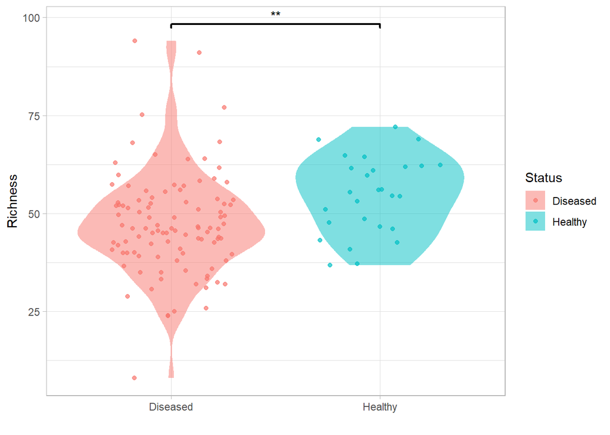

```r
# richness plot

metrics |>
  ggplot() +
  aes(x = status, y = richness, fill = status, color = status) +
  geom_violin(color = NA, alpha = 0.5) +
  geom_point(position = position_jitter(width = 0.3), alpha = 0.7, size = 1.5) +
  labs(x = "", y = "Richness", fill = "Status", color = "Status") +
    stat_compare_means(
    comparisons = list(c("Healthy", "Diseased")),
    method = "wilcox.test",
    label = "p.signif",
    tip.length = 0.01,
    bracket.size = 0.8,
    fontface = "bold"
  )
```

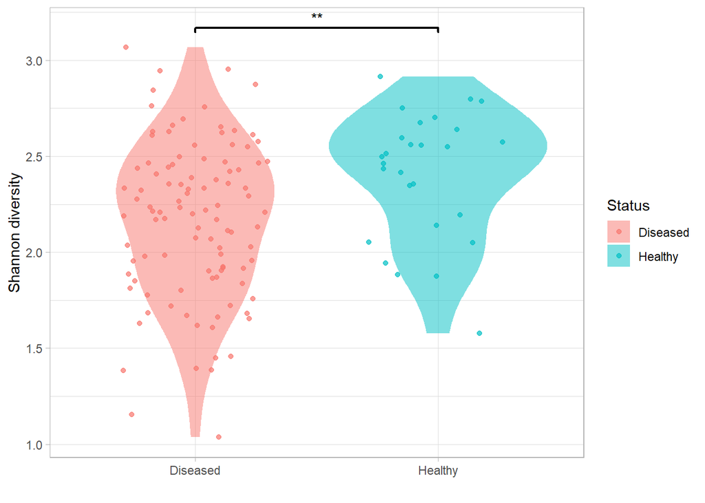

```r
# shannon diversity plot

metrics |>
  ggplot() +
  aes(x = status, y = shannon, fill = status, color = status) +
  geom_violin(color = NA, alpha = 0.5) +
  geom_point(position = position_jitter(width = 0.3), alpha = 0.7, size = 1.5) +
  labs(x = "", y = "Shannon diversity", fill = "Status", color = "Status") +
    stat_compare_means(
    comparisons = list(c("Healthy", "Diseased")),
    method = "wilcox.test",
    label = "p.signif",
    tip.length = 0.01,
    bracket.size = 0.8,
    fontface = "bold"
  )
```

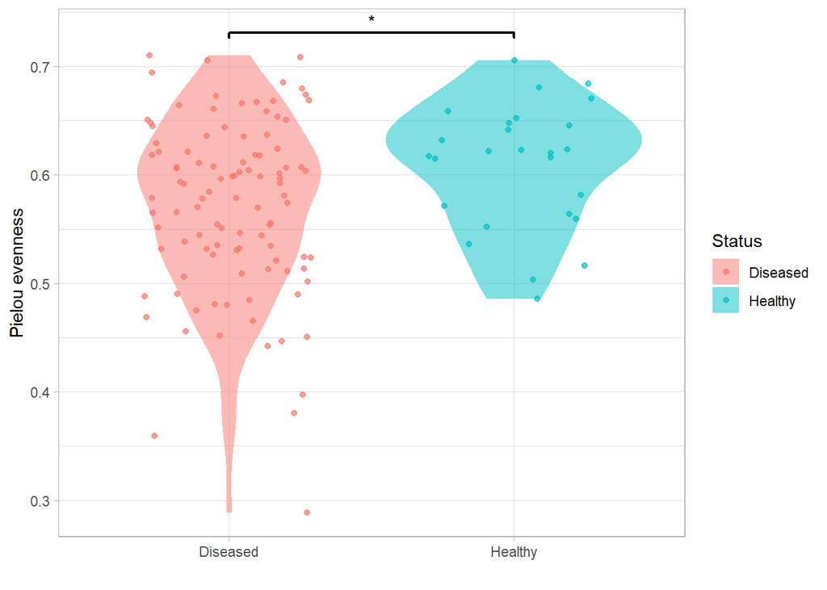

```r
# Pielou evenness plot

metrics |>
  ggplot() +
  aes(x = status, y = pielou, fill = status, color = status) +
  geom_violin(color = NA, alpha = 0.5) +
  geom_point(position = position_jitter(width = 0.3), alpha = 0.7, size = 1.5) +
  labs(x = "", y = "Pielou evenness", fill = "Status", color = "Status") +
    stat_compare_means(
    comparisons = list(c("Healthy", "Diseased")),
    method = "wilcox.test",
    label = "p.signif",
    tip.length = 0.01,
    bracket.size = 0.8,
    fontface = "bold"
  )
```

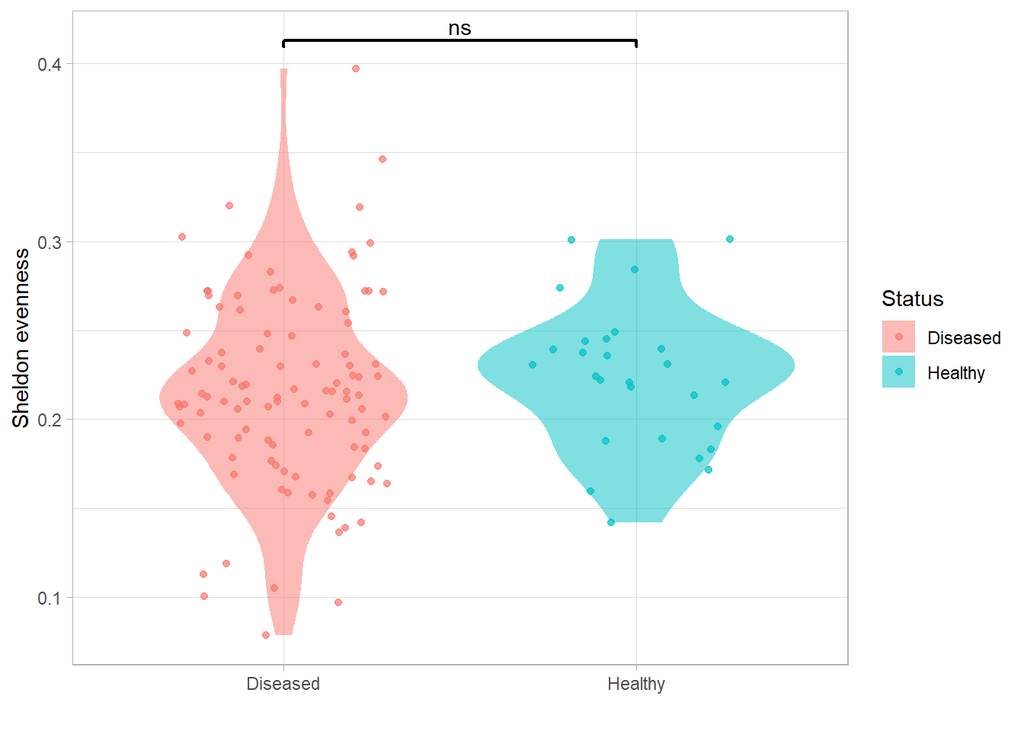

```r
# Sheldon evenness plot

metrics |>
  ggplot() +
  aes(x = status, y = sheldon, fill = status, color = status) +
  geom_violin(color = NA, alpha = 0.5) +
  geom_point(position = position_jitter(width = 0.3), alpha = 0.7, size = 1.5) +
  labs(x = "", y = "Sheldon evenness", fill = "Status", color = "Status") +
    stat_compare_means(
    comparisons = list(c("Healthy", "Diseased")),
    method = "wilcox.test",
    label = "p.signif",
    tip.length = 0.01,
    bracket.size = 0.8,
    fontface = "bold"
  )
```

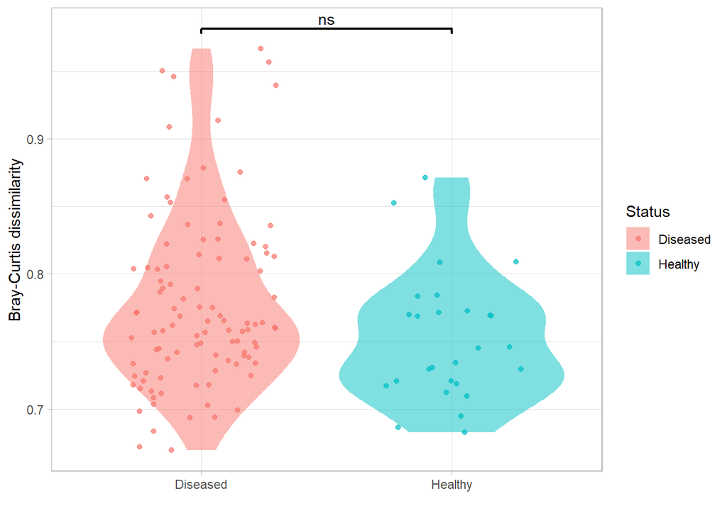

```r
# Bray Curtis plot

metrics |>
  ggplot() +
  aes(x = status, y = bc, fill = status, color = status) +
  geom_violin(color = NA, alpha = 0.5) +
  geom_point(position = position_jitter(width = 0.3), alpha = 0.7, size = 1.5) +
  labs(x = "", y = "Bray-Curtis dissimilarity", fill = "Status", color = "Status") +
    stat_compare_means(
    comparisons = list(c("Healthy", "Diseased")),
    method = "wilcox.test",
    label = "p.signif",
    tip.length = 0.01,
    bracket.size = 0.8,
    fontface = "bold"
  )
```

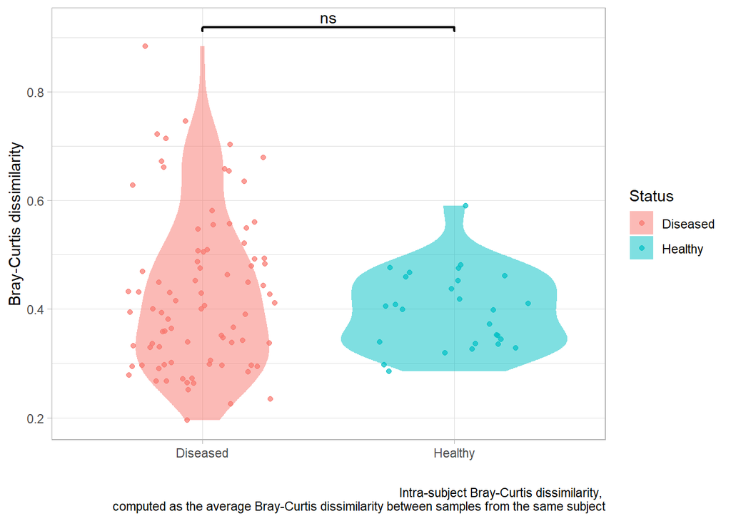

```r
# Bray Curtis plot

metrics |>
  ggplot() +
  aes(x = status, y = bc_intra, fill = status, color = status) +
  geom_violin(color = NA, alpha = 0.5) +
  geom_point(position = position_jitter(width = 0.3), alpha = 0.7, size = 1.5) +
  labs(x = "", y = "Bray-Curtis dissimilarity", fill = "Status", color = "Status",
       caption = "Intra-subject Bray-Curtis dissimilarity, \ncomputed as the average Bray-Curtis dissimilarity between samples from the same subject") +
    stat_compare_means(
    comparisons = list(c("Healthy", "Diseased")),
    method = "wilcox.test",
    label = "p.signif",
    tip.length = 0.01,
    bracket.size = 0.8,
    fontface = "bold"
  )
```

## IBS cohort (Mars et al., 2020)

We first import the IBS dataset from the MAE object in the chunk code below.

```r
tmp <-
  mae[["IBS"]] |>
  assay() |>
  t() |>
  as.data.frame() |>
  rownames_to_column("uid") |>
  pivot_longer(-uid, names_to = "taxon", values_to = "count") |>
  group_by(uid) |>
  mutate(rel_ab = count/sum(count)) |>
  left_join(
    mae[["IBS"]] |> colData() |> as_tibble(rownames = "uid") |> select(uid, pid, time, cohort),
    by = join_by(uid)
  )
```

```r
tmp |>
  group_by(pid, cohort) |>
  summarise(n_samples = n_distinct(uid), .groups = "drop") |>
  gt(caption = "Number of samples in the IBS dataset, separated by study and cohort") |>
  tab_options(
    container.height = px(400)
  )
```

Number of samples in the IBS dataset, separated by study and cohort

| pid | cohort | n_samples |
| --- | --- | --- |
| 10007541 | H | 2 |
| 10007542 | C | 1 |
| 10007544 | D | 2 |
| 10007547 | C | 2 |
| 10007548 | C | 2 |
| 10007549 | H | 2 |
| 10007554 | D | 1 |
| 10007556 | C | 2 |
| 10007557 | H | 2 |
| 10007559 | D | 2 |
| 10007561 | D | 1 |
| 10007562 | H | 2 |
| 10007563 | H | 2 |
| 10007564 | H | 2 |
| 10007565 | D | 2 |
| 10007566 | D | 1 |
| 10007567 | D | 2 |
| 10007569 | H | 2 |
| 10007572 | D | 2 |
| 10007578 | D | 1 |
| 10007581 | D | 2 |
| 10007583 | C | 1 |
| 10007584 | D | 2 |
| 10007587 | H | 2 |
| 10007589 | C | 1 |
| 10007590 | D | 2 |
| 10007594 | D | 2 |
| 10007595 | C | 2 |
| 10007599 | H | 1 |
| 10007600 | D | 1 |
| 10007602 | C | 1 |
| 10007603 | H | 1 |
| 10007605 | H | 1 |
| 10007606 | C | 1 |
| 10007607 | C | 1 |
| 10007608 | C | 2 |
| 10007611 | C | 2 |
| 10007616 | H | 2 |

We compute the number of taxa and samples in the dataset, to get an sense of the size of the dataset.

```r
n_taxa <- mae[["IBS"]] |> assay() |> nrow()
cat("Number of taxa:", n_taxa, "\n")
```

```
Number of taxa: 598
```

```r
n_samples <- mae[["IBS"]] |> assay() |> ncol()
cat("Number of samples:", n_samples, "\n")
```

```
Number of samples: 62
```

```r
# separate healthy and IBS samples

mae[["IBS"]] |>
  colData() |>
  as.data.frame() |>
  as_tibble(rownames = "uid") |>
  mutate(
    status = case_when(
      cohort == "H" ~ "Healthy",
      cohort == "C" ~ "Diseased",
      cohort == "D" ~ "Diseased"
    ),
    status = factor(status)
  ) |>
  dplyr::count(status) |>
  gt(caption = "Number of healthy and diseased samples in the IBS dataset")
```

Number of healthy and diseased samples in the IBS dataset

| status | n |
| --- | --- |
| Diseased | 41 |
| Healthy | 21 |

- Richness = $\sum_{i=1}^{S} I(x_i > 0)$, where $S$ is the total number of taxa and $x_i$ is the abundance of taxon $i$ in the sample.
- Shannon = $-\sum_{i=1}^{S} p_i \log(p_i)$, where $p_i$ is the relative abundance of taxon $i$ in the sample.
- Pielou’s evenness = $\frac{-\sum_{i=1}^{S} p_i \log(p_i)}{\log(\sum_{i=1}^{S} I(x_i > 0))}$
- Sheldon evenness = $\frac{exp(-\sum_{i=1}^{S} p_i \log(p_i))}{\sum_{i=1}^{S} I(x_i > 0)}$
- Beta diversity will be computed using Bray-Curtis dissimilarity.

The difference between groups will be assessed using the Wilcoxon rank-sum test.

```r
bc_mat <- tmp |>
  select(uid, taxon, rel_ab) |>
  pivot_wider(names_from = taxon, values_from = rel_ab) |>
  column_to_rownames("uid") |>
  as.matrix()
```

```r
bc_per_sample <- vegan::vegdist(bc_mat, method = "bray") |>
  as.matrix() |>
  rowMeans() |>
  as_tibble(rownames = "uid") |>
  dplyr::rename(bc = value)
```

```r
bc_long <- vegan::vegdist(bc_mat, method = "bray") |>
  as.matrix() |>
  as_tibble(rownames = "sample1") |>
  pivot_longer(-sample1, names_to = "sample2", values_to = "bc") |>
  filter(sample1 < sample2)

sample_meta <- mae[["IBS"]] |>
  colData() |>
  as.data.frame() |>
  as_tibble(rownames = "uid") |>
  select(uid, pid, cohort)

bc_intra <- bc_long |>
  select(sample1, sample2, bc) |>
  left_join(sample_meta, by = c("sample1" = "uid")) |>
  select(sample1, sample2, bc, subject1 = pid, cohort1 = cohort) |>
  left_join(sample_meta, by = c("sample2" = "uid")) |>
  select(sample1, sample2, bc, subject1, cohort1, subject2 = pid, cohort2 = cohort) |>
  filter(subject1 == subject2) |>
  group_by(subject1, cohort1) |>
  summarise(bc_intra = mean(bc), .groups = "drop") |>
  select(pid = subject1, cohort = cohort1, bc_intra)
```

```r
metrics <- tmp |>
  group_by(uid) |>
  summarise(
    richness = sum(rel_ab > 0),
    shannon = vegan::diversity(rel_ab, index = "shannon"),
    pielou = shannon / log(richness),
    sheldon = exp(shannon) / richness,
    .groups = "drop"
  ) |>
  left_join(bc_per_sample, by = "uid") |>
  left_join(
    mae[["IBS"]] |> colData() |> as.data.frame() |> as_tibble(rownames = "uid") |>
      select(uid, pid, time, cohort),
    by = join_by(uid)
  ) |>
  group_by(pid, cohort) |>
  summarise(across(c(richness, shannon, pielou, sheldon, bc), mean), .groups = "drop") |>
  left_join(bc_intra, by = join_by(pid, cohort)) |>
  mutate(
    status = case_when(
      cohort == "H"   ~ "Healthy",
      cohort == "C" ~ "Diseased",
      cohort == "D" ~ "Diseased"
    ),
    status = factor(status)
  )
```

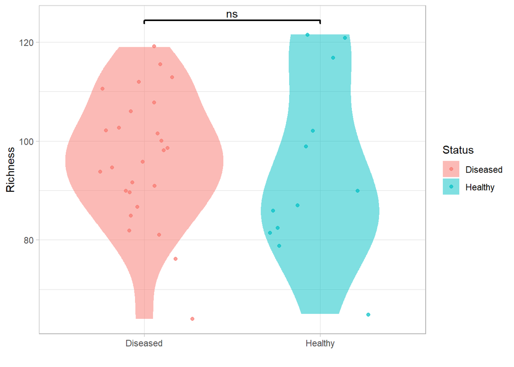

```r
# richness plot

metrics |>
  ggplot() +
  aes(x = status, y = richness, fill = status, color = status) +
  geom_violin(color = NA, alpha = 0.5) +
  geom_point(position = position_jitter(width = 0.3), alpha = 0.7, size = 1.5) +
  labs(x = "", y = "Richness", fill = "Status", color = "Status") +
    stat_compare_means(
    comparisons = list(c("Healthy", "Diseased")),
    method = "wilcox.test",
    label = "p.signif",
    tip.length = 0.01,
    bracket.size = 0.8,
    fontface = "bold"
  )
```

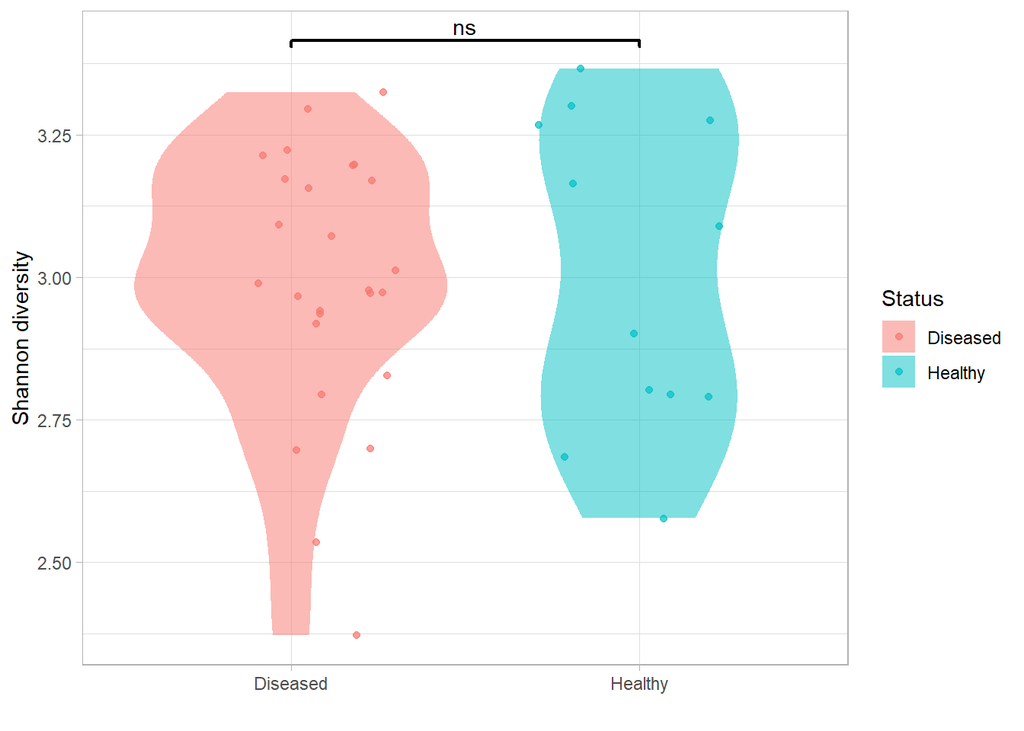

```r
# shannon diversity plot

metrics |>
  ggplot() +
  aes(x = status, y = shannon, fill = status, color = status) +
  geom_violin(color = NA, alpha = 0.5) +
  geom_point(position = position_jitter(width = 0.3), alpha = 0.7, size = 1.5) +
  labs(x = "", y = "Shannon diversity", fill = "Status", color = "Status") +
    stat_compare_means(
    comparisons = list(c("Healthy", "Diseased")),
    method = "wilcox.test",
    label = "p.signif",
    tip.length = 0.01,
    bracket.size = 0.8,
    fontface = "bold"
  )
```

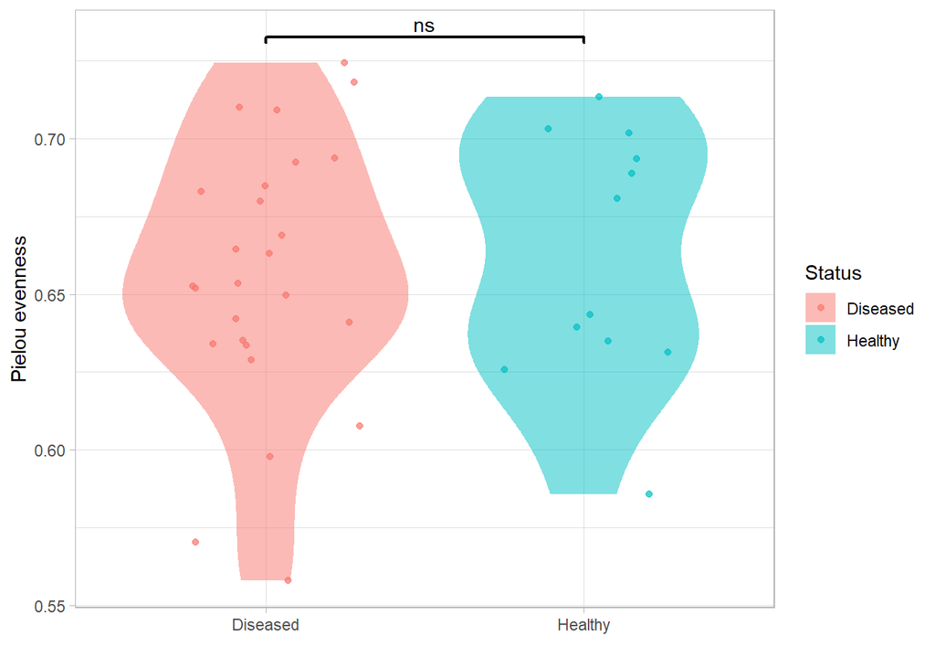

```r
# Pielou evenness plot

metrics |>
  ggplot() +
  aes(x = status, y = pielou, fill = status, color = status) +
  geom_violin(color = NA, alpha = 0.5) +
  geom_point(position = position_jitter(width = 0.3), alpha = 0.7, size = 1.5) +
  labs(x = "", y = "Pielou evenness", fill = "Status", color = "Status") +
    stat_compare_means(
    comparisons = list(c("Healthy", "Diseased")),
    method = "wilcox.test",
    label = "p.signif",
    tip.length = 0.01,
    bracket.size = 0.8,
    fontface = "bold"
  )
```

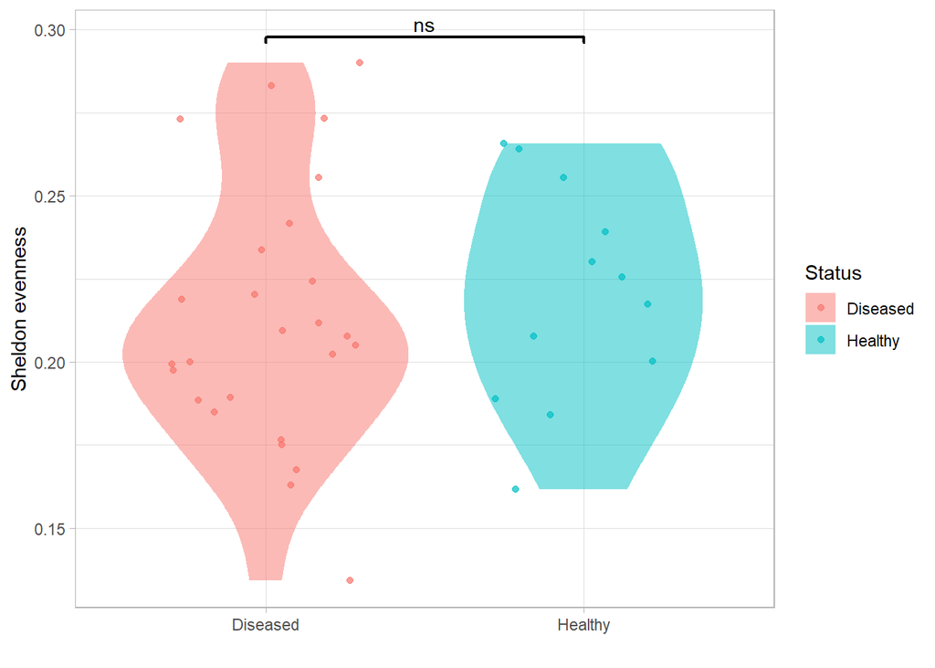

```r
# Sheldon evenness plot

metrics |>
  ggplot() +
  aes(x = status, y = sheldon, fill = status, color = status) +
  geom_violin(color = NA, alpha = 0.5) +
  geom_point(position = position_jitter(width = 0.3), alpha = 0.7, size = 1.5) +
  labs(x = "", y = "Sheldon evenness", fill = "Status", color = "Status") +
    stat_compare_means(
    comparisons = list(c("Healthy", "Diseased")),
    method = "wilcox.test",
    label = "p.signif",
    tip.length = 0.01,
    bracket.size = 0.8,
    fontface = "bold"
  )
```

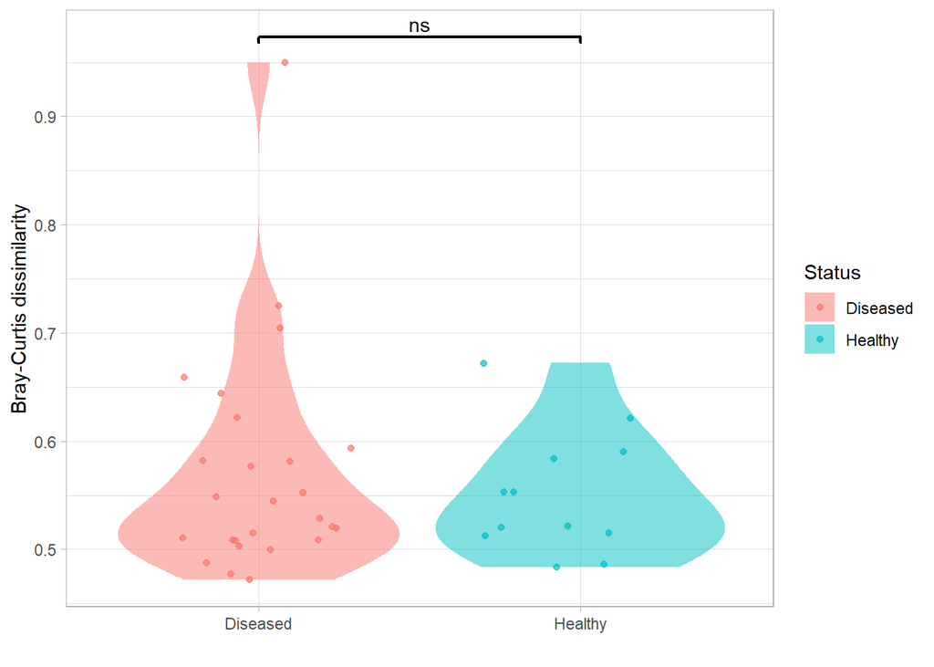

```r
# Inter subject Bray Curtis plot

metrics |>
  ggplot() +
  aes(x = status, y = bc, fill = status, color = status) +
  geom_violin(color = NA, alpha = 0.5) +
  geom_point(position = position_jitter(width = 0.3), alpha = 0.7, size = 1.5) +
  labs(x = "", y = "Bray-Curtis dissimilarity", fill = "Status", color = "Status") +
    stat_compare_means(
    comparisons = list(c("Healthy", "Diseased")),
    method = "wilcox.test",
    label = "p.signif",
    tip.length = 0.01,
    bracket.size = 0.8,
    fontface = "bold"
  )
```

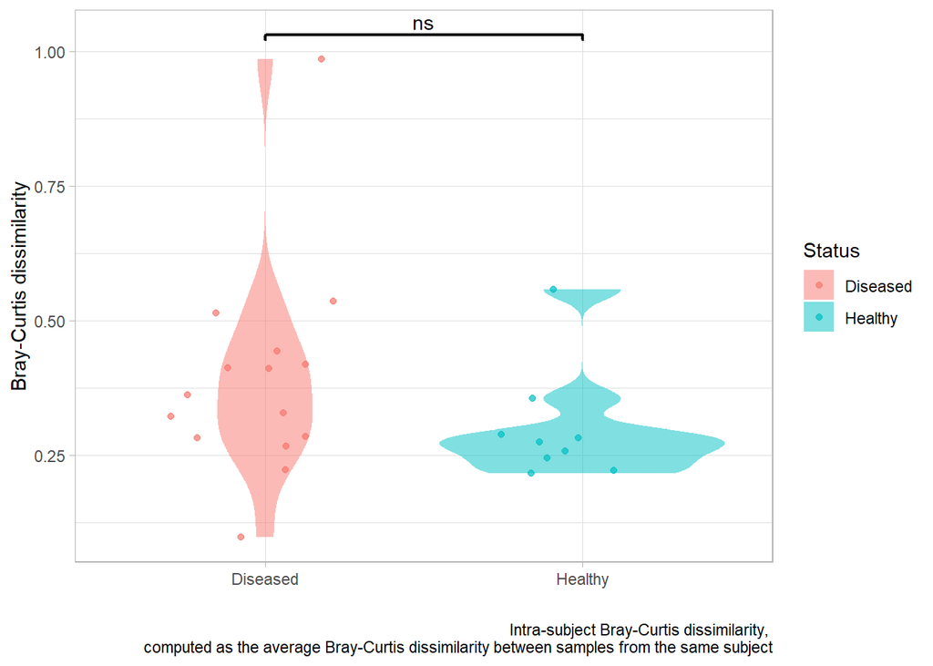

```r
# Intra subject Bray Curtis plot

metrics |>
  ggplot() +
  aes(x = status, y = bc_intra, fill = status, color = status) +
  geom_violin(color = NA, alpha = 0.5) +
  geom_point(position = position_jitter(width = 0.3), alpha = 0.7, size = 1.5) +
  labs(x = "", y = "Bray-Curtis dissimilarity", fill = "Status", color = "Status",
       caption = "Intra-subject Bray-Curtis dissimilarity, \ncomputed as the average Bray-Curtis dissimilarity between samples from the same subject") +
    stat_compare_means(
    comparisons = list(c("Healthy", "Diseased")),
    method = "wilcox.test",
    label = "p.signif",
    tip.length = 0.01,
    bracket.size = 0.8,
    fontface = "bold"
  )
```

**Note**

## CRC cohort (Ferretti et al., 2022)

```r
tmp <-
  mae[["CRC"]] |>
  assay() |>
  t() |>
  as.data.frame() |>
  rownames_to_column("sample_id") |>
  pivot_longer(-sample_id, names_to = "taxon", values_to = "rel_ab") |>
  left_join(
    mae[["CRC"]] |> colData() |> as_tibble(rownames = "sample_id") |> select(sample_id, group, cohort),
    by = join_by(sample_id)
  )
```

We compute the number of taxa and samples in the dataset, to get an sense of the size of the dataset.

```r
n_taxa <- mae[["CRC"]] |> assay() |> nrow()
cat("Number of taxa:", n_taxa, "\n")
```

```
Number of taxa: 837
```

```r
n_samples <- mae[["CRC"]] |> assay() |> ncol()
cat("Number of samples:", n_samples, "\n")
```

```
Number of samples: 575
```

```r
# separate healthy and CRC samples

mae[["CRC"]] |>
  colData() |>
  as.data.frame() |>
  as_tibble(rownames = "sample_id") |>
  dplyr::count(cohort) |>
  gt(caption = "Number of healthy and diseased samples in the CRC dataset")
```

Number of healthy and diseased samples in the CRC dataset

| cohort | n |
| --- | --- |
| CRC | 324 |
| H | 251 |

**Important**

We will compute beta diversity, evenness, and richness measures on the CRC dataset. We will use the `vegan` package to compute these metrics.

- Richness = $\sum_{i=1}^{S} I(x_i > 0)$, where $S$ is the total number of taxa and $x_i$ is the abundance of taxon $i$ in the sample.
- Shannon = $-\sum_{i=1}^{S} p_i \log(p_i)$, where $p_i$ is the relative abundance of taxon $i$ in the sample.
- Pielou’s evenness = $\frac{-\sum_{i=1}^{S} p_i \log(p_i)}{\log(\sum_{i=1}^{S} I(x_i > 0))}$
- Sheldon evenness = $\frac{exp(-\sum_{i=1}^{S} p_i \log(p_i))}{\sum_{i=1}^{S} I(x_i > 0)}$
- Beta diversity will be computed using Bray-Curtis dissimilarity.

The difference between groups will be assessed using the Wilcoxon rank-sum test.

```r
bc_mat <- tmp |>
  select(sample_id, taxon, rel_ab) |>
  pivot_wider(names_from = taxon, values_from = rel_ab) |>
  column_to_rownames("sample_id") |>
  as.matrix()
```

```r
bc_per_sample <- vegan::vegdist(bc_mat, method = "bray") |>
  as.matrix() |>
  rowMeans() |>
  as_tibble(rownames = "sample_id") |>
  dplyr::rename(bc = value)
```

```r
metrics <- tmp |>
  group_by(sample_id) |>
  summarise(
    richness = sum(rel_ab > 0),
    shannon  = vegan::diversity(rel_ab, index = "shannon"),
    pielou   = shannon / log(richness),
    sheldon  = exp(shannon) / richness,
    .groups  = "drop"
  ) |>
  left_join(bc_per_sample, by = "sample_id") |>
  left_join(
    mae[["CRC"]] |> colData() |> as_tibble(rownames = "sample_id") |> select(sample_id, group, cohort),
    by = join_by(sample_id)
  ) |>
  group_by(sample_id, cohort) |>
  summarise(across(c(richness, shannon, pielou, sheldon, bc), mean), .groups = "drop")
```

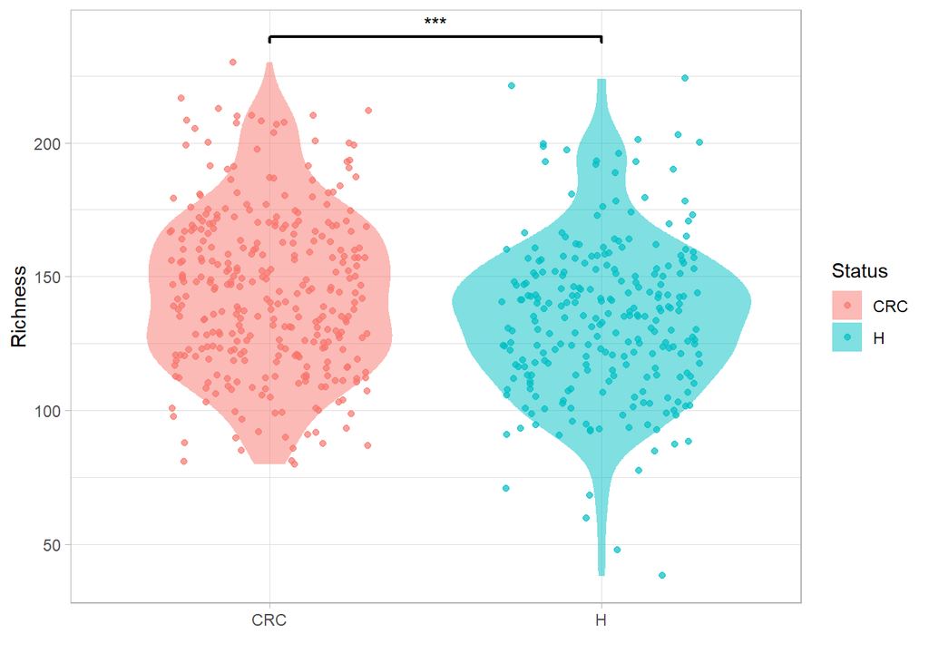

```r
# richness plot

metrics |>
  ggplot() +
  aes(x = cohort, y = richness, fill = cohort, color = cohort) +
  geom_violin(color = NA, alpha = 0.5) +
  geom_point(position = position_jitter(width = 0.3), alpha = 0.7, size = 1.5) +
  labs(x = "", y = "Richness", fill = "Status", color = "Status") +
    stat_compare_means(
    comparisons = list(c("H", "CRC")),
    method = "wilcox.test",
    label = "p.signif",
    tip.length = 0.01,
    bracket.size = 0.8,
    fontface = "bold"
  )
```

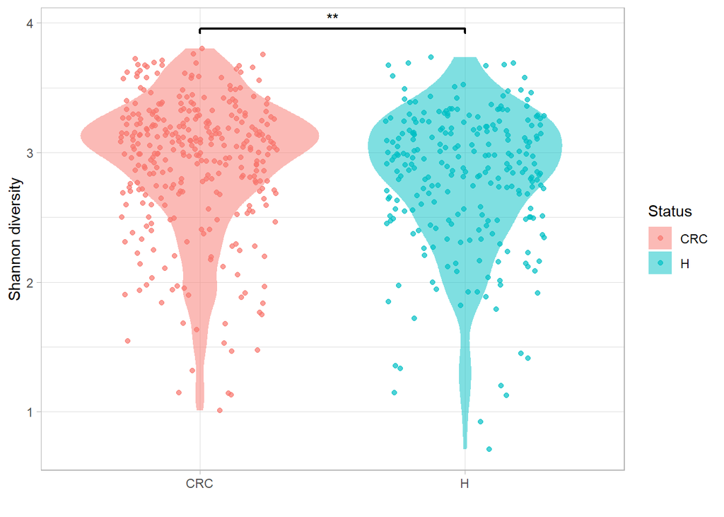

```r
# shannon diversity plot

metrics |>
  ggplot() +
  aes(x = cohort, y = shannon, fill = cohort, color = cohort) +
  geom_violin(color = NA, alpha = 0.5) +
  geom_point(position = position_jitter(width = 0.3), alpha = 0.7, size = 1.5) +
  labs(x = "", y = "Shannon diversity", fill = "Status", color = "Status") +
    stat_compare_means(
    comparisons = list(c("H", "CRC")),
    method = "wilcox.test",
    label = "p.signif",
    tip.length = 0.01,
    bracket.size = 0.8,
    fontface = "bold"
  )
```

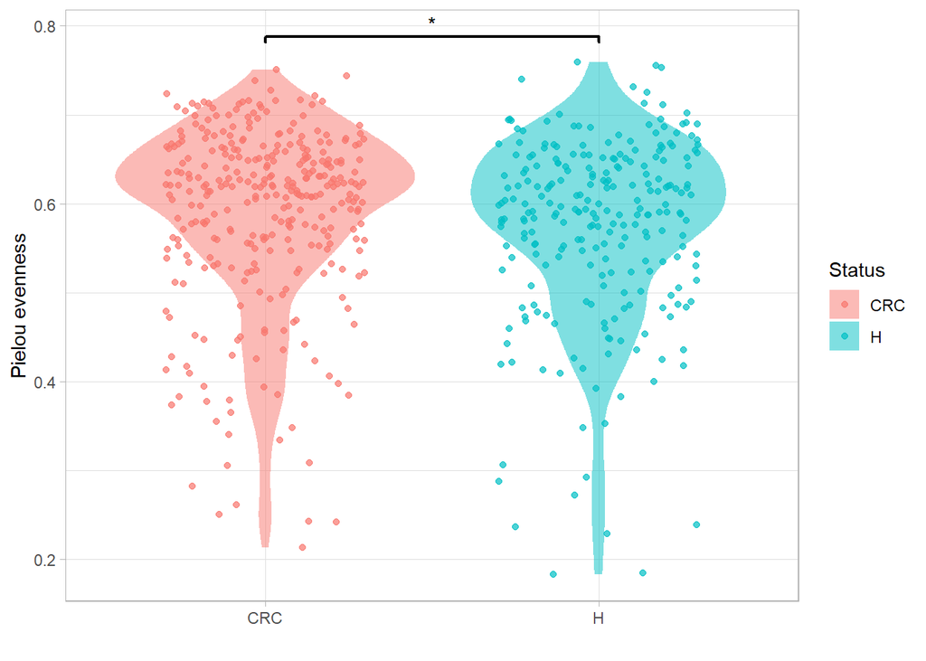

```r
# Pielou evenness plot

metrics |>
  ggplot() +
  aes(x = cohort, y = pielou, fill = cohort, color = cohort) +
  geom_violin(color = NA, alpha = 0.5) +
  geom_point(position = position_jitter(width = 0.3), alpha = 0.7, size = 1.5) +
  labs(x = "", y = "Pielou evenness", fill = "Status", color = "Status") +
    stat_compare_means(
    comparisons = list(c("H", "CRC")),
    method = "wilcox.test",
    label = "p.signif",
    tip.length = 0.01,
    bracket.size = 0.8,
    fontface = "bold"
  )
```

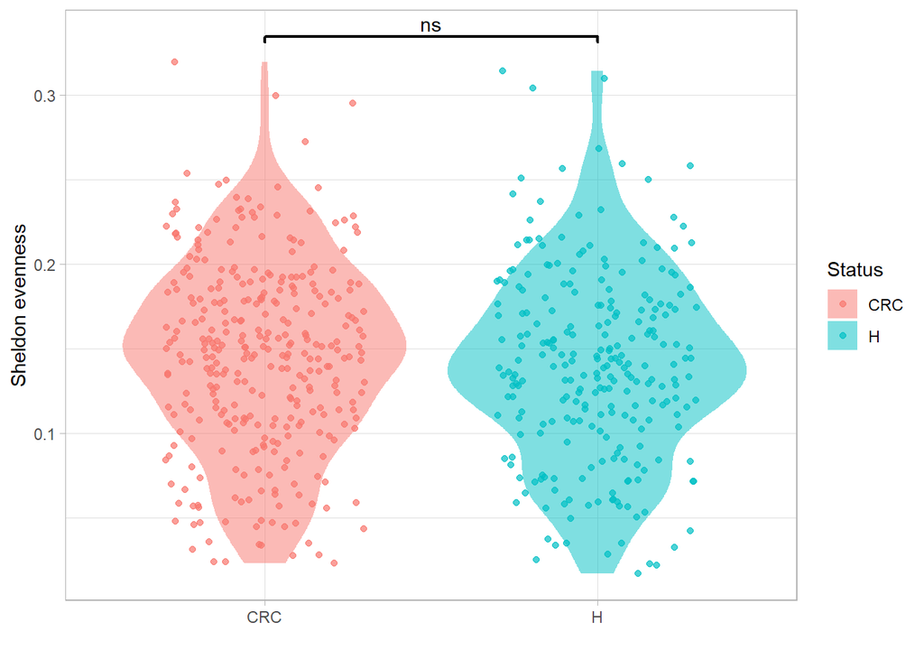

```r
# Sheldon evenness plot

metrics |>
  ggplot() +
  aes(x = cohort, y = sheldon, fill = cohort, color = cohort) +
  geom_violin(color = NA, alpha = 0.5) +
  geom_point(position = position_jitter(width = 0.3), alpha = 0.7, size = 1.5) +
  labs(x = "", y = "Sheldon evenness", fill = "Status", color = "Status") +
    stat_compare_means(
    comparisons = list(c("H", "CRC")),
    method = "wilcox.test",
    label = "p.signif",
    tip.length = 0.01,
    bracket.size = 0.8,
    fontface = "bold"
  )
```

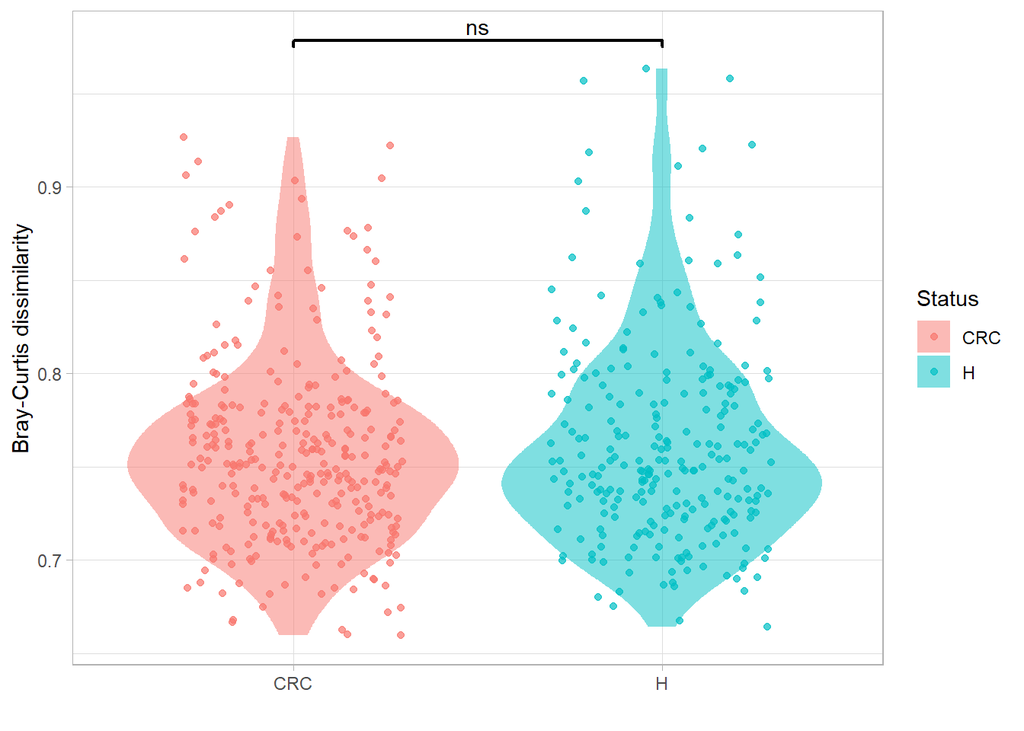

```r
# Bray Curtis plot

metrics |>
  ggplot() +
  aes(x = cohort, y = bc, fill = cohort, color = cohort) +
  geom_violin(color = NA, alpha = 0.5) +
  geom_point(position = position_jitter(width = 0.3), alpha = 0.7, size = 1.5) +
  labs(x = "", y = "Bray-Curtis dissimilarity", fill = "Status", color = "Status") +
    stat_compare_means(
    comparisons = list(c("H", "CRC")),
    method = "wilcox.test",
    label = "p.signif",
    tip.length = 0.01,
    bracket.size = 0.8,
    fontface = "bold"
  )
```

## CDI cohort (Yashida et al., 2020)

```r
tmp <-
  mae[["CDI"]] |>
  assay() |>
  t() |>
  as.data.frame() |>
  rownames_to_column("sample_id") |>
  pivot_longer(-sample_id, names_to = "taxon", values_to = "count") |>
  group_by(sample_id) |>
  mutate(rel_ab = count/sum(count)) |>
  left_join(
    mae[["CDI"]] |> colData() |> as_tibble(rownames = "sample_id") |> select(sample_id, status, subject_disease_status),
    by = join_by(sample_id)
  ) |>
  filter(subject_disease_status == "CDI" | subject_disease_status == "CTR")
```

We compute the number of taxa and samples in the dataset, to get an sense of the size of the dataset.

```r
n_taxa <- mae[["CDI"]] |> assay() |> nrow()
cat("Number of taxa:", n_taxa, "\n")
```

```
Number of taxa: 868
```

```r
n_samples <- mae[["CDI"]] |> assay() |> ncol()
cat("Number of samples:", n_samples, "\n")
```

```
Number of samples: 366
```

```r
# separate healthy and CDI samples

mae[["CDI"]] |>
  colData() |>
  as.data.frame() |>
  as_tibble(rownames = "sample_id") |>
  dplyr::count(status) |>
  gt(caption = "Number of healthy and diseased samples in the CDI dataset")
```

Number of healthy and diseased samples in the CDI dataset

| status | n |
| --- | --- |
| Diseased | 234 |
| Healthy | 132 |

- Richness = $\sum_{i=1}^{S} I(x_i > 0)$, where $S$ is the total number of taxa and $x_i$ is the abundance of taxon $i$ in the sample.
- Shannon = $-\sum_{i=1}^{S} p_i \log(p_i)$, where $p_i$ is the relative abundance of taxon $i$ in the sample.
- Pielou’s evenness = $\frac{-\sum_{i=1}^{S} p_i \log(p_i)}{\log(\sum_{i=1}^{S} I(x_i > 0))}$
- Sheldon evenness = $\frac{exp(-\sum_{i=1}^{S} p_i \log(p_i))}{\sum_{i=1}^{S} I(x_i > 0)}$
- Beta diversity will be computed using Bray-Curtis dissimilarity.

The difference between groups will be assessed using the Wilcoxon rank-sum test.

```r
bc_mat <- tmp |>
  select(sample_id, taxon, rel_ab) |>
  pivot_wider(names_from = taxon, values_from = rel_ab) |>
  column_to_rownames("sample_id") |>
  as.matrix()
```

```r
bc_per_sample <- vegan::vegdist(bc_mat, method = "bray") |>
  as.matrix() |>
  rowMeans() |>
  as_tibble(rownames = "sample_id") |>
  dplyr::rename(bc = value)
```

```r
metrics <- tmp |>
  group_by(sample_id) |>
  summarise(
    richness = sum(rel_ab > 0),
    shannon  = vegan::diversity(rel_ab, index = "shannon"),
    pielou   = shannon / log(richness),
    sheldon  = exp(shannon) / richness,
    .groups  = "drop"
  ) |>
  left_join(bc_per_sample, by = "sample_id") |>
  left_join(
    mae[["CDI"]] |> colData() |> as.data.frame() |> as_tibble(rownames = "sample_id") |>
      select(sample_id, status),
    by = join_by(sample_id)
  ) |>
  group_by(sample_id, status) |>
  summarise(across(c(richness, shannon, pielou, sheldon, bc), mean), .groups = "drop")
```

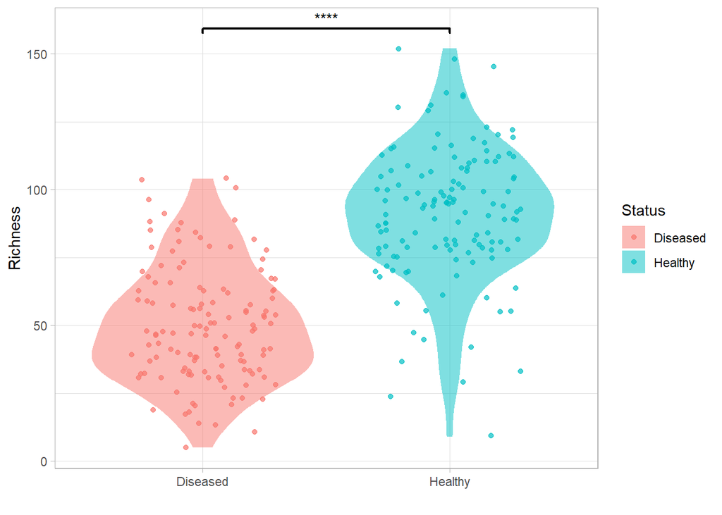

```r
# richness plot

metrics |>
  ggplot() +
  aes(x = status, y = richness, fill = status, color = status) +
  geom_violin(color = NA, alpha = 0.5) +
  geom_point(position = position_jitter(width = 0.3), alpha = 0.7, size = 1.5) +
  labs(x = "", y = "Richness", fill = "Status", color = "Status") +
    stat_compare_means(
    comparisons = list(c("Healthy", "Diseased")),
    method = "wilcox.test",
    label = "p.signif",
    tip.length = 0.01,
    bracket.size = 0.8,
    fontface = "bold"
  )
```

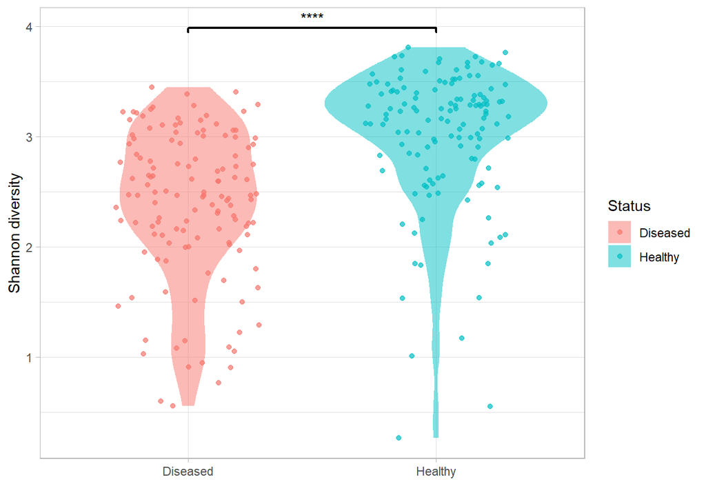

```r
# shannon diversity plot

metrics |>
  ggplot() +
  aes(x = status, y = shannon, fill = status, color = status) +
  geom_violin(color = NA, alpha = 0.5) +
  geom_point(position = position_jitter(width = 0.3), alpha = 0.7, size = 1.5) +
  labs(x = "", y = "Shannon diversity", fill = "Status", color = "Status") +
    stat_compare_means(
    comparisons = list(c("Healthy", "Diseased")),
    method = "wilcox.test",
    label = "p.signif",
    tip.length = 0.01,
    bracket.size = 0.8,
    fontface = "bold"
  )
```

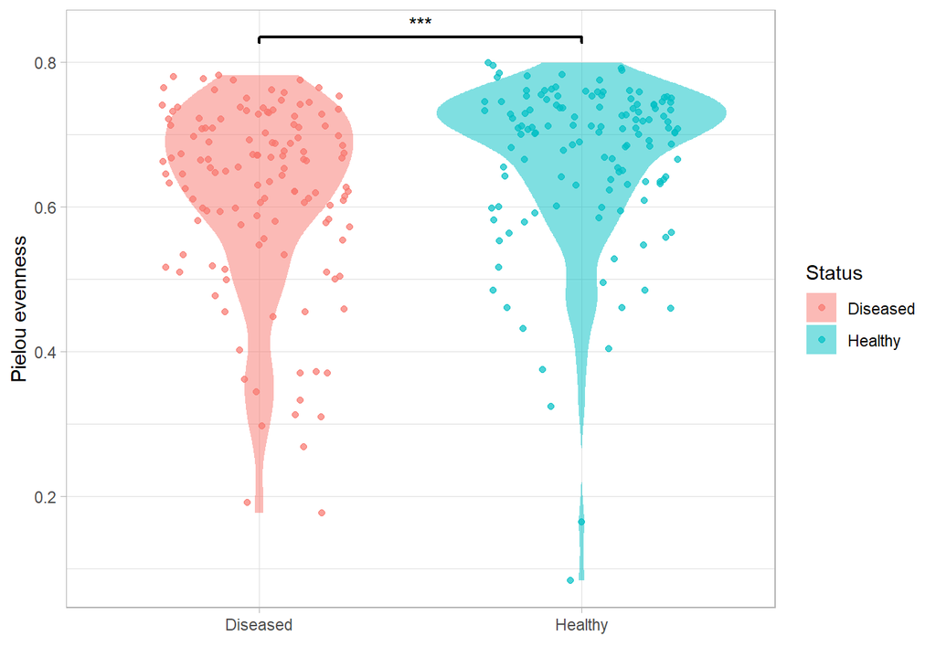

```r
# Pielou evenness plot

metrics |>
  ggplot() +
  aes(x = status, y = pielou, fill = status, color = status) +
  geom_violin(color = NA, alpha = 0.5) +
  geom_point(position = position_jitter(width = 0.3), alpha = 0.7, size = 1.5) +
  labs(x = "", y = "Pielou evenness", fill = "Status", color = "Status") +
    stat_compare_means(
    comparisons = list(c("Healthy", "Diseased")),
    method = "wilcox.test",
    label = "p.signif",
    tip.length = 0.01,
    bracket.size = 0.8,
    fontface = "bold"
  )
```

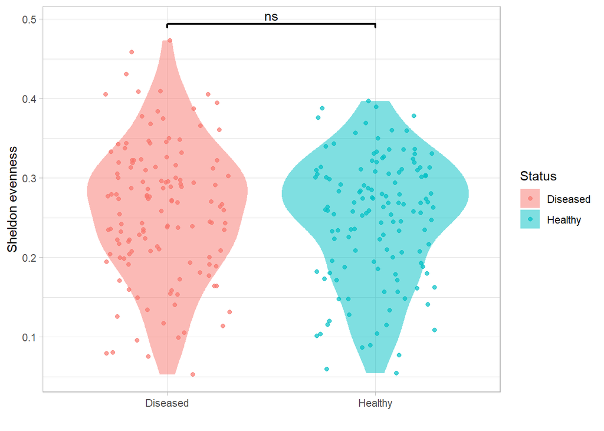

```r
# Sheldon evenness plot

metrics |>
  ggplot() +
  aes(x = status, y = sheldon, fill = status, color = status) +
  geom_violin(color = NA, alpha = 0.5) +
  geom_point(position = position_jitter(width = 0.3), alpha = 0.7, size = 1.5) +
  labs(x = "", y = "Sheldon evenness", fill = "Status", color = "Status") +
    stat_compare_means(
    comparisons = list(c("Healthy", "Diseased")),
    method = "wilcox.test",
    label = "p.signif",
    tip.length = 0.01,
    bracket.size = 0.8,
    fontface = "bold"
  )
```

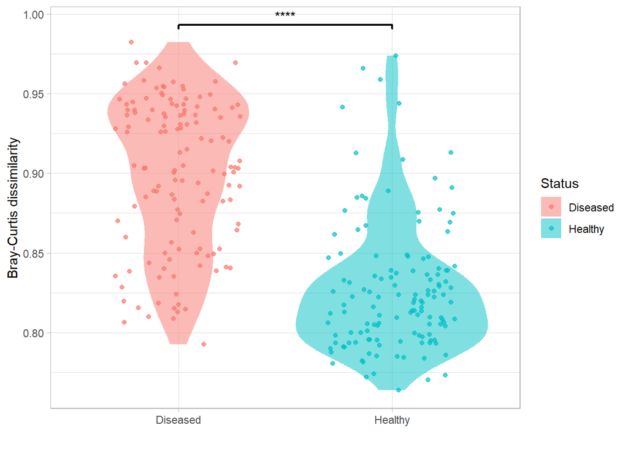

```r
# Bray Curtis plot

metrics |>
  ggplot() +
  aes(x = status, y = bc, fill = status, color = status) +
  geom_violin(color = NA, alpha = 0.5) +
  geom_point(position = position_jitter(width = 0.3), alpha = 0.7, size = 1.5) +
  labs(x = "", y = "Bray-Curtis dissimilarity", fill = "Status", color = "Status") +
    stat_compare_means(
    comparisons = list(c("Healthy", "Diseased")),
    method = "wilcox.test",
    label = "p.signif",
    tip.length = 0.01,
    bracket.size = 0.8,
    fontface = "bold"
  )
```